# RNASeq_Analysis

Hui Xin Ng

2022-09-06

This dataset used is from [PMID: 25049118](https://pubmed.ncbi.nlm.nih.gov/25049118/) obtained from [EMBL-EBI expression atlas](https://www.ebi.ac.uk/gxa/experiments/E-GEOD-50760/Downloads?ref=biostudies). There are 54 samples from 18 individuals. Each individual has 3 samples (normal colon, primary CRC, and liver metastases). Genes associated with colorectal cancer (CRC) aggressiveness were identified.

```r
options(warn=-1)
packages <- c( "dplyr", "DESeq2", "pheatmap", "enrichR", "msigdbr", "tidyverse", "biomaRt", "org.Hs.eg.db", "EnhancedVolcano", "kableExtra", "RColorBrewer", "pheatmap", "reshape2", "ggplot2", "fgsea")

installed_packages <- packages %in% rownames(installed.packages())
if (any(installed_packages == FALSE)) {
  install.packages(packages[!installed_packages])}

invisible(lapply(packages, library, character.only = TRUE))
```

```r
# read count info
rawCounts <- read.delim("E-GEOD-50760-raw-counts.tsv")
# Read sample info
sampleData <- read.delim("E-GEOD-50760-experiment-design.tsv")
# head(sampleData) # there are 16 columns on info/description about each of the 54 samples
```

# Step 1: preparing count data and sample info

```r
# store readcounts and other calcs for DSEq
# obj also stores design formula to estimate dispersion and log2 fold changes

# Convert count data to a matrix
geneID <- rawCounts$Gene.ID # get a list of the gene name from the col Gene.ID
sampleIndex <- grepl("SRR\\d+", colnames(rawCounts))
rawCounts <- as.matrix(rawCounts[,sampleIndex])
rownames(rawCounts) <- geneID # use gene names as rownames
# matrix with genes as row names, and samples as col names

ens <- rownames(rawCounts)
symbols <- mapIds(org.Hs.eg.db, keys = ens, column = c('SYMBOL'), keytype = 'ENSEMBL')

symbols <- symbols[!is.na(symbols)]
symbols <- symbols[match(rownames(rawCounts), names(symbols))]

rownames(rawCounts) <- symbols
keep <- !is.na(rownames(rawCounts))
rawCounts <- rawCounts[keep,]
```

```r
# map samples to variables, keep only 2 columns on tissue type and person ID
rownames(sampleData) <- sampleData$Run
keep <- c("Sample.Characteristic.biopsy.site.", "Sample.Characteristic.individual.")
sampleData <- sampleData[,keep]
# rename cols
colnames(sampleData) <- c("tissueType", "personID")
sampleData$personID <- factor(sampleData$personID)

sampleData <- sampleData %>%
    mutate(tissueType = str_replace_all(tissueType, " ", "_"))
# head(sampleData)
```

```r
# ensure colnames of the count matrix are in same order as the row names of the sample mapping data
rawCounts <- rawCounts[,unique(rownames(sampleData))]
all(colnames(rawCounts) == rownames(sampleData))
```

# Step 2: construct a DESeqDataSet object

```r
deseq2Data <- DESeqDataSetFromMatrix(countData=rawCounts, colData=sampleData, design= ~ personID + tissueType) # person id as a blocking factor and tissue type as the comparison variable.
deseq2Data$tissueType <- relevel(deseq2Data$tissueType, ref = "normal")
```

# Step 3: Run DESeq

```r
deseq2Data <- DESeq(deseq2Data)
```

```r
# extract the DE results using results()
# use contrast parameter to take in a char vector of three elements
# Compare between primary tumor vs. normal
deseq2Results_colorectal <- results(deseq2Data, contrast=c("tissueType", "primary_tumor", "normal"), alpha = 0.01)
deseq2Results_colorectal <- deseq2Results_colorectal[order(deseq2Results_colorectal$padj),]

deseq2Results_liver <- results(deseq2Data, contrast=c("tissueType", "colorectal_cancer_metastatic_in_the_liver", "normal"),  alpha = 0.01)
deseq2Results_liver <- deseq2Results_liver[order(deseq2Results_liver$padj),]
```

# Step 4: Explore Results

How many genes are up- and down-regulated? How many genes have low counts?

```r
# normal vs. colorectal cancer
summary(deseq2Results_colorectal)
```

```
##
## out of 27082 with nonzero total read count
## adjusted p-value < 0.01
## LFC > 0 (up)       : 2405, 8.9%
## LFC < 0 (down)     : 2673, 9.9%
## outliers [1]       : 0, 0%
## low counts [2]     : 8786, 32%
## (mean count < 2)
## [1] see 'cooksCutoff' argument of ?results
## [2] see 'independentFiltering' argument of ?results
```

```r
# normal vs. metastatic liver sample
summary(deseq2Results_liver)
```

```
##
## out of 27082 with nonzero total read count
## adjusted p-value < 0.01
## LFC > 0 (up)       : 4017, 15%
## LFC < 0 (down)     : 4095, 15%
## outliers [1]       : 0, 0%
## low counts [2]     : 8269, 31%
## (mean count < 1)
## [1] see 'cooksCutoff' argument of ?results
## [2] see 'independentFiltering' argument of ?results
```

# Step 5: Visualization

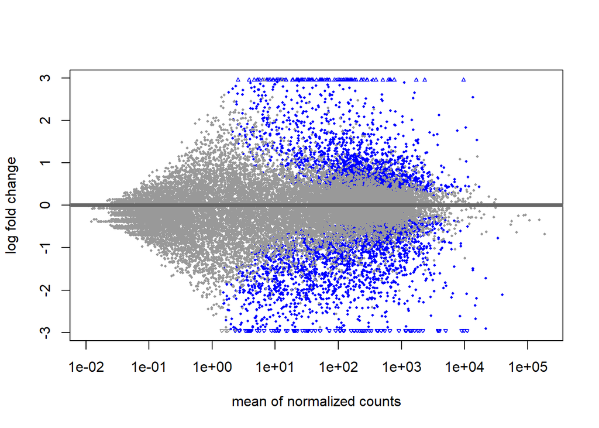

```r
# MA plot to show log ratio (M) vs. an average (A) in order to visualize differences between groups
plotMA(deseq2Results_colorectal)
```

## PCA plot by tissue type

Rlog transformation is applied to the normalized counts to produce a variance-stabilizing effect, similar to vst().

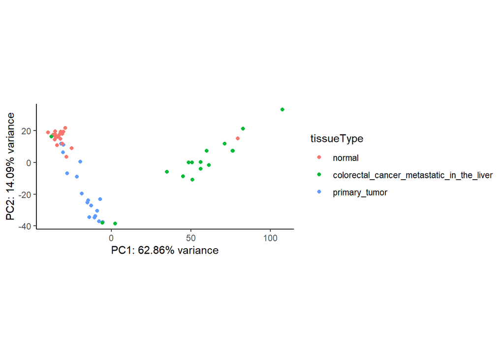

```r
#jpeg('PCA.jpg')
rld<-rlogTransformation(deseq2Data,blind=TRUE, fitType='local')
pca_data <- plotPCA(rld, intgroup="tissueType", returnData = TRUE)
percentVar <- round(100 * attr(pca_data, "percentVar"), digits=2)
pca_plot <- ggplot(pca_data, aes(PC1, PC2, color=tissueType)) + geom_point() +
  scale_x_continuous(paste0("PC1: ",percentVar[1],"% variance")) +
  scale_y_continuous(paste0("PC2: ",percentVar[2],"% variance"))  + coord_fixed() + theme_classic()
pca_plot
```

```r
#dev.off()
```

## Volcano plot

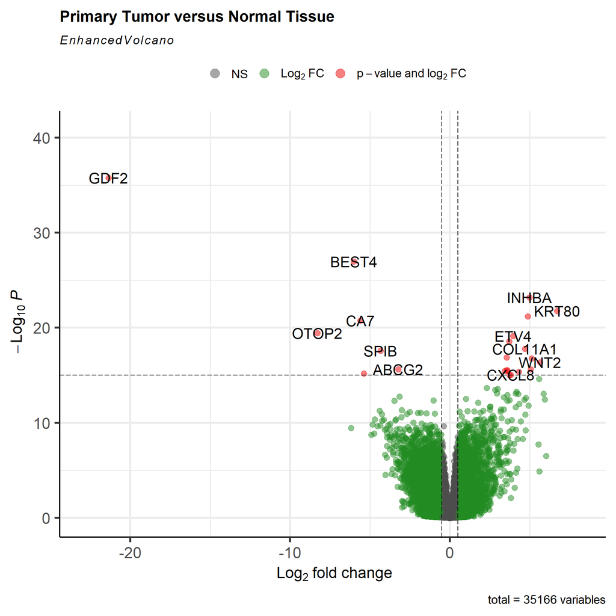

```r
volcano_plot <- EnhancedVolcano(deseq2Results_colorectal,
    lab = rownames(deseq2Results_colorectal),
    x = 'log2FoldChange',
    y = 'pvalue',
    title = 'Primary Tumor versus Normal Tissue',
    pCutoff = 10e-16,
    FCcutoff = 0.5,
    pointSize = 3.0,
    labSize = 6.0)
volcano_plot
```